# Course Project

Margerys Salgado

14/6/2019

# Background

Using devices such as Jawbone Up, Nike FuelBand, and Fitbit it is now possible to collect a large amount of data about personal activity relatively inexpensively.

These type of devices are part of the quantified self movement a group of enthusiasts who take measurements about themselves regularly to improve their health, to find patterns in their behavior, or because they are tech geeks.

One thing that people regularly do is quantify how much of a particular activity they do, but they rarely quantify how well they do it.

In this project, your goal will be to use data(6 participants) from accelerometers on the: - belt (cintura), - forearm (antebrazo), - arm (brazo),

They were asked to perform barbell lifts correctly and incorrectly in 5 different ways.

More information is available from the website here: http://groupware.les.inf.puc-rio.br/har (see the section on the Weight Lifting Exercise Dataset).

# Data

The training data for this project are available here: https://d396qusza40orc.cloudfront.net/predmachlearn/pml-training.csv

The test data are available here: https://d396qusza40orc.cloudfront.net/predmachlearn/pml-testing.csv

The data for this project come from this source: http://groupware.les.inf.puc-rio.br/har.

If you use the document you create for this class for any purpose please cite them as they have been very generous in allowing their data to be used for this kind of assignment.

# What you should submit

- The goal of your project is to predict the manner in which they did the exercise.
- This is the “classe” variable in the training set.
- You may use any of the other variables to predict with.
- You should create a report describing how you built your model, how you used cross validation, what you think the expected out of sample error is, and why you made the choices you did.
- You will also use your prediction model to predict 20 different test cases.

## Peer Review Portion

- Your submission for the Peer Review portion should consist of a link to a Github repo with your R markdown and compiled HTML file describing your analysis.
- Please constrain the text of the writeup to < 2000 words and the number of figures to be less than 5. It will make it easier for the graders if you submit a repo with a gh-pages branch so the HTML page can be viewed online (and you always want to make it easy on graders :-).

## Course Project Prediction Quiz Portion

Apply your machine learning algorithm to the 20 test cases available in the test data above and submit your predictions in appropriate format to the Course Project Prediction Quiz for automated grading.

# Reproducibility

Due to security concerns with the exchange of R code, your code will not be run during the evaluation by your classmates. Please be sure that if they download the repo, they will be able to view the compiled HTML version of your analysis.

# Librerias Utilizadas

```r
rm(list = ls())

library(ggplot2)
library(caret)
library(pgmm)
library(rpart)
library(rpart.plot)
library(e1071)
library(rpart)
library(rattle)
library(tidyverse)
library(randomForest)
library(readabs)
library(gbm)
library(knitr)
set.seed(12345)
```

## Data

Download the training and testing data sets from the given URLs. We are trying to predict the outcome of the variable classe in the training set.

```r
# The training data:
training <- read.csv(url("https://d396qusza40orc.cloudfront.net/predmachlearn/pml-training.csv"), na.strings = c("NA", ""))

# The test data:
testing <- read.csv(url("https://d396qusza40orc.cloudfront.net/predmachlearn/pml-testing.csv"), na.strings = c("NA", ""))

inTrain  <- createDataPartition(training$classe, p=0.7, list=FALSE)
TrainD <- training[inTrain, ]
TestD  <- training[-inTrain, ]

dim(TrainD)
```

```
[1] 13737   160
```

```r
dim(TestD)
```

```
[1] 5885  160
```

## Limpieza de data

Delete columns (predictors) of the training set that contain any missing values. Remove variables with Nearly Zero Variance, mostly NA and identification only variables (columns 1 to 5).

```r
NZV <- nearZeroVar(TrainD)
TrainD <- TrainD[, -NZV]
TestD  <- TestD[, -NZV]

AllNA    <- sapply(TrainD, function(x) mean(is.na(x))) > 0.95
TrainD <- TrainD[, AllNA==FALSE]
TestD  <- TestD[, AllNA==FALSE]

TrainD <- TrainD[, -(1:5)]
TestD  <- TestD[, -(1:5)]

dim(TrainD)
```

```
[1] 13737    54
```

```r
dim(TestD)
```

```
[1] 5885   54
```

## create a partition with the training dataset

Split the cleaned training set trainData into a training set (train, 70%) for prediction and a validation set (valid 30%) to compute the out-of-sample errors.

```r
inTrain <- createDataPartition(TrainD$classe, p = 0.7, list = FALSE)
train <- TrainD[inTrain, ]
test <- TrainD[-inTrain, ]

dim(TrainD)
```

```
[1] 13737    54
```

```r
dim(TestD)
```

```
[1] 5885   54
```

## Prediction Model Building

### Method: Random Forest

```r
set.seed(12345)
control1 <- trainControl(method="cv", number=3, verboseIter=FALSE)

modFit1 <- train(classe ~., data=TrainD, method="rf", trControl=control1)

names(modFit1)
```

```
 [1] "method"       "modelInfo"    "modelType"    "results"
 [5] "pred"         "bestTune"     "call"         "dots"
 [9] "metric"       "control"      "finalModel"   "preProcess"
[13] "trainingData" "resample"     "resampledCM"  "perfNames"
[17] "maximize"     "yLimits"      "times"        "levels"
[21] "terms"        "coefnames"    "xlevels"
```

```r
print(modFit1$finalModel)
```

```
Call:
 randomForest(x = x, y = y, mtry = param$mtry)
               Type of random forest: classification
                     Number of trees: 500
No. of variables tried at each split: 27

        OOB estimate of  error rate: 0.23%
Confusion matrix:
     A    B    C    D    E  class.error
A 3904    2    0    0    0 0.0005120328
B    6 2647    4    1    0 0.0041384500
C    0    5 2391    0    0 0.0020868114
D    0    0    9 2243    0 0.0039964476
E    0    0    0    5 2520 0.0019801980
```

```r
predict1 <- predict(modFit1, newdata=TestD)
confMat1 <- confusionMatrix(predict1, TestD$classe)
confMat1
```

```
Confusion Matrix and Statistics

          Reference
Prediction    A    B    C    D    E
         A 1674    1    0    0    0
         B    0 1138    2    0    0
         C    0    0 1024    2    0
         D    0    0    0  962    1
         E    0    0    0    0 1081

Overall Statistics

               Accuracy : 0.999
                 95% CI : (0.9978, 0.9996)
    No Information Rate : 0.2845
    P-Value [Acc > NIR] : < 2.2e-16

                  Kappa : 0.9987

 Mcnemar's Test P-Value : NA

Statistics by Class:

                     Class: A Class: B Class: C Class: D Class: E
Sensitivity            1.0000   0.9991   0.9981   0.9979   0.9991
Specificity            0.9998   0.9996   0.9996   0.9998   1.0000
Pos Pred Value         0.9994   0.9982   0.9981   0.9990   1.0000
Neg Pred Value         1.0000   0.9998   0.9996   0.9996   0.9998
Prevalence             0.2845   0.1935   0.1743   0.1638   0.1839
Detection Rate         0.2845   0.1934   0.1740   0.1635   0.1837
Detection Prevalence   0.2846   0.1937   0.1743   0.1636   0.1837
Balanced Accuracy      0.9999   0.9994   0.9988   0.9989   0.9995
```

```r
confMat1$overall
```

```
      Accuracy          Kappa  AccuracyLower  AccuracyUpper   AccuracyNull
     0.9989805      0.9987104      0.9977822      0.9996258      0.2844520
AccuracyPValue  McnemarPValue
     0.0000000            NaN
```

### Method: Decision Trees

```r
set.seed(12345)

modFit2 <- train(classe ~., method= "rpart", data = TrainD)
modFit2
```

```
CART

13737 samples
   53 predictor
    5 classes: 'A', 'B', 'C', 'D', 'E'

No pre-processing
Resampling: Bootstrapped (25 reps)
Summary of sample sizes: 13737, 13737, 13737, 13737, 13737, 13737, ...
Resampling results across tuning parameters:

  cp          Accuracy   Kappa
  0.03839894  0.5459164  0.41360357
  0.06092971  0.4038307  0.18597295
  0.11595972  0.3406163  0.08456319

Accuracy was used to select the optimal model using the largest value.
The final value used for the model was cp = 0.03839894.
```

```r
names(modFit2)
```

```
 [1] "method"       "modelInfo"    "modelType"    "results"
 [5] "pred"         "bestTune"     "call"         "dots"
 [9] "metric"       "control"      "finalModel"   "preProcess"
[13] "trainingData" "resample"     "resampledCM"  "perfNames"
[17] "maximize"     "yLimits"      "times"        "levels"
[21] "terms"        "coefnames"    "xlevels"
```

```r
print(modFit2$finalModel)
```

```
n= 13737

node), split, n, loss, yval, (yprob)
      * denotes terminal node

 1) root 13737 9831 A (0.28 0.19 0.17 0.16 0.18)
   2) roll_belt< 130.5 12577 8681 A (0.31 0.21 0.19 0.18 0.11)
     4) pitch_forearm< -33.95 1107    9 A (0.99 0.0081 0 0 0) *
     5) pitch_forearm>=-33.95 11470 8672 A (0.24 0.23 0.21 0.2 0.12)
      10) magnet_dumbbell_y< 439.5 9738 6992 A (0.28 0.18 0.24 0.19 0.11)
        20) roll_forearm< 123.5 6030 3573 A (0.41 0.18 0.18 0.17 0.062) *
        21) roll_forearm>=123.5 3708 2471 C (0.078 0.18 0.33 0.23 0.18) *
      11) magnet_dumbbell_y>=439.5 1732  831 B (0.03 0.52 0.041 0.22 0.19) *
   3) roll_belt>=130.5 1160   10 E (0.0086 0 0 0 0.99) *
```

[figure not shown]

```r
plot(modFit2$finalModel, uniform = TRUE, main="classification Trees")
```

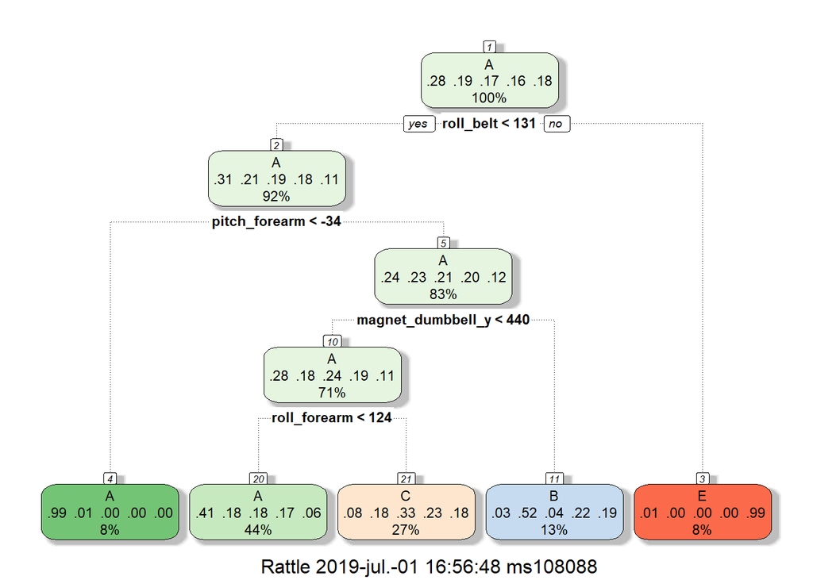

```r
fancyRpartPlot(modFit2$finalModel)
```

```r
predict(modFit2, newdata = TestD)
```

[output not shown]

[output cut: 160 more lines]

```r
predict2 <- predict(modFit2, newdata = TestD, type="raw")

confMat2 <- confusionMatrix(predict2, TestD$classe)
confMat2
```

```
Confusion Matrix and Statistics

          Reference
Prediction    A    B    C    D    E
         A 1525  484  499  423  153
         B   29  385   37  187  159
         C  116  270  490  354  289
         D    0    0    0    0    0
         E    4    0    0    0  481

Overall Statistics

               Accuracy : 0.4895
                 95% CI : (0.4767, 0.5024)
    No Information Rate : 0.2845
    P-Value [Acc > NIR] : < 2.2e-16

                  Kappa : 0.3324

 Mcnemar's Test P-Value : NA

Statistics by Class:

                     Class: A Class: B Class: C Class: D Class: E
Sensitivity            0.9110  0.33802  0.47758   0.0000  0.44455
Specificity            0.6298  0.91319  0.78823   1.0000  0.99917
Pos Pred Value         0.4945  0.48306  0.32258      NaN  0.99175
Neg Pred Value         0.9468  0.85181  0.87723   0.8362  0.88870
Prevalence             0.2845  0.19354  0.17434   0.1638  0.18386
Detection Rate         0.2591  0.06542  0.08326   0.0000  0.08173
Detection Prevalence   0.5240  0.13543  0.25811   0.0000  0.08241
Balanced Accuracy      0.7704  0.62560  0.63291   0.5000  0.72186
```

```r
confMat2$overall
```

```
      Accuracy          Kappa  AccuracyLower  AccuracyUpper   AccuracyNull
  4.895497e-01   3.323704e-01   4.767009e-01   5.024089e-01   2.844520e-01
AccuracyPValue  McnemarPValue
 3.867046e-241            NaN
```

### Method: Generalized Boosted Model

```r
set.seed(12345)

modFit3 <- train(classe ~., method="gbm", data = train, verbose = FALSE)
modFit3
```

```
Stochastic Gradient Boosting

9619 samples
  53 predictor
   5 classes: 'A', 'B', 'C', 'D', 'E'

No pre-processing
Resampling: Bootstrapped (25 reps)
Summary of sample sizes: 9619, 9619, 9619, 9619, 9619, 9619, ...
Resampling results across tuning parameters:

  interaction.depth  n.trees  Accuracy   Kappa
  1                   50      0.7604188  0.6959230
  1                  100      0.8285659  0.7828949
  1                  150      0.8673985  0.8321192
  2                   50      0.8814013  0.8497622
  2                  100      0.9345204  0.9171186
  2                  150      0.9564142  0.9448329
  3                   50      0.9282196  0.9091169
  3                  100      0.9645793  0.9551682
  3                  150      0.9792951  0.9737961

Tuning parameter 'shrinkage' was held constant at a value of 0.1

Tuning parameter 'n.minobsinnode' was held constant at a value of 10
Accuracy was used to select the optimal model using the largest value.
The final values used for the model were n.trees = 150,
 interaction.depth = 3, shrinkage = 0.1 and n.minobsinnode = 10.
```

```r
names(modFit3)
```

```
 [1] "method"       "modelInfo"    "modelType"    "results"
 [5] "pred"         "bestTune"     "call"         "dots"
 [9] "metric"       "control"      "finalModel"   "preProcess"
[13] "trainingData" "resample"     "resampledCM"  "perfNames"
[17] "maximize"     "yLimits"      "times"        "levels"
[21] "terms"        "coefnames"    "xlevels"
```

```r
print(modFit3$finalModel)
```

```
A gradient boosted model with multinomial loss function.
150 iterations were performed.
There were 53 predictors of which 53 had non-zero influence.
```

```r
predict3 <- predict(modFit3, newdata=TestD)
confMat3 <- confusionMatrix(predict3, TestD$classe)
confMat3
```

```
Confusion Matrix and Statistics

          Reference
Prediction    A    B    C    D    E
         A 1672   13    0    0    0
         B    1 1109   14    3    5
         C    0   13 1003   23    2
         D    0    4    8  937    6
         E    1    0    1    1 1069

Overall Statistics

               Accuracy : 0.9839
                 95% CI : (0.9803, 0.9869)
    No Information Rate : 0.2845
    P-Value [Acc > NIR] : < 2.2e-16

                  Kappa : 0.9796

 Mcnemar's Test P-Value : NA

Statistics by Class:

                     Class: A Class: B Class: C Class: D Class: E
Sensitivity            0.9988   0.9737   0.9776   0.9720   0.9880
Specificity            0.9969   0.9952   0.9922   0.9963   0.9994
Pos Pred Value         0.9923   0.9797   0.9635   0.9812   0.9972
Neg Pred Value         0.9995   0.9937   0.9953   0.9945   0.9973
Prevalence             0.2845   0.1935   0.1743   0.1638   0.1839
Detection Rate         0.2841   0.1884   0.1704   0.1592   0.1816
Detection Prevalence   0.2863   0.1924   0.1769   0.1623   0.1822
Balanced Accuracy      0.9979   0.9844   0.9849   0.9842   0.9937
```

```r
confMat3$overall
```

```
      Accuracy          Kappa  AccuracyLower  AccuracyUpper   AccuracyNull
     0.9838573      0.9795769      0.9803019      0.9869204      0.2844520
AccuracyPValue  McnemarPValue
     0.0000000            NaN
```

## Selected Model to the Test Data

The accuracy of the 3 regression modeling methods. The first method was selected: modFit1: Method Random Forest

```r
confMat1$overall ### modFit1: Method Random Forest
```

```
      Accuracy          Kappa  AccuracyLower  AccuracyUpper   AccuracyNull
     0.9989805      0.9987104      0.9977822      0.9996258      0.2844520
AccuracyPValue  McnemarPValue
     0.0000000            NaN
```

```r
confMat2$overall ### modFit2: Method Decision Trees
```

```
      Accuracy          Kappa  AccuracyLower  AccuracyUpper   AccuracyNull
  4.895497e-01   3.323704e-01   4.767009e-01   5.024089e-01   2.844520e-01
AccuracyPValue  McnemarPValue
 3.867046e-241            NaN
```

```r
confMat3$overall ### modFit3: Method Generalized Boosted Model
```

```
      Accuracy          Kappa  AccuracyLower  AccuracyUpper   AccuracyNull
     0.9838573      0.9795769      0.9803019      0.9869204      0.2844520
AccuracyPValue  McnemarPValue
     0.0000000            NaN
```

```r
predictTEST <- predict(modFit1, newdata=testing)
predictTEST
```

```
 [1] B A B A A E D B A A B C B A E E A B B B
Levels: A B C D E
```